# Session 5

Callin Switzer

Oct 15, 2015

*Note: this is the final class. Feel free to contact me for help with R or statistics. cswitzer@fas.harvard.edu*

I can help with these things:

1. non-parametric analysis (permutation tests, rank-sum, bootstrap, etc).
2. interactive visualizations using ggvis package
3. drawing maps in R
4. generalized linear models (count data, logistic regression, skewed data)
5. analyses for repeated measures (linear mixed effects models, generalized linear mixed effects models)
6. What to do when the assumptions of your test are not met (robust regression, transformations, etc.)
7. Correcting p-values for multiple comparisons.
8. Model selection methods (stepwise procedures, likelihood ratio tests, analysis of deviance)

I can’t help very much with these things:

1. Phylogenetic analyses
2. Bioninformatics

#### Topics:

- Loops and apply functions()
- Writing your own functions

```
## [1] "Last knit to html at:  2015-10-13 11:09:45"
```

# Review

#### What we learned last time:

1. Visualization with ggplot
- adding lines
- changing order or bars / boxes
- changing color scheme

Exercises(0):

### 0.1 Set your working directory to the Session5 folder.

```r
# 0.1
setwd("/Users/callinswitzer/Dropbox/Harvard/RByCall/RClassMaterials/Session5")
```

# Loops and apply functions

```r
################################  EXAMPLE 1 ################################
# for and while loops
################################  EXAMPLE 1 ################################
# for loops repeat a specific number of times
for(i in 1:10){
     print(i + 100)
}
```

```
## [1] 101
## [1] 102
## [1] 103
## [1] 104
## [1] 105
## [1] 106
## [1] 107
## [1] 108
## [1] 109
## [1] 110
```

```r
# make fake data
df1 <- data.frame(person = c("bob", "sue", "jack", "ann"), number1 = c(4,5,6,1), number2 = c(2,4,6,6))
df1
```

```
##   person number1 number2
## 1    bob       4       2
## 2    sue       5       4
## 3   jack       6       6
## 4    ann       1       6
```

```r
# another for loop
for(ii in df1$person){
    print(rep(ii, times = df1[df1$person == ii, "number1"]))
}
```

```
## [1] "bob" "bob" "bob" "bob"
## [1] "sue" "sue" "sue" "sue" "sue"
## [1] "jack" "jack" "jack" "jack" "jack" "jack"
## [1] "ann"
```

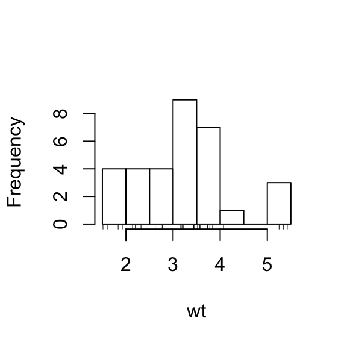

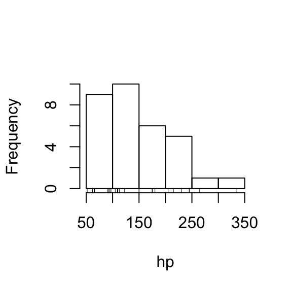

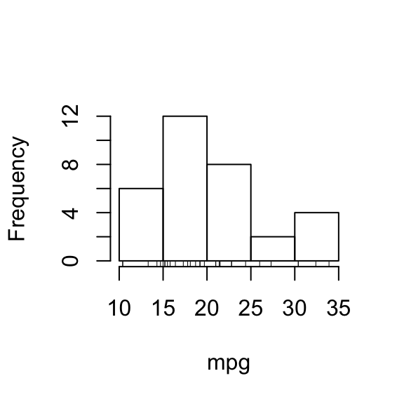

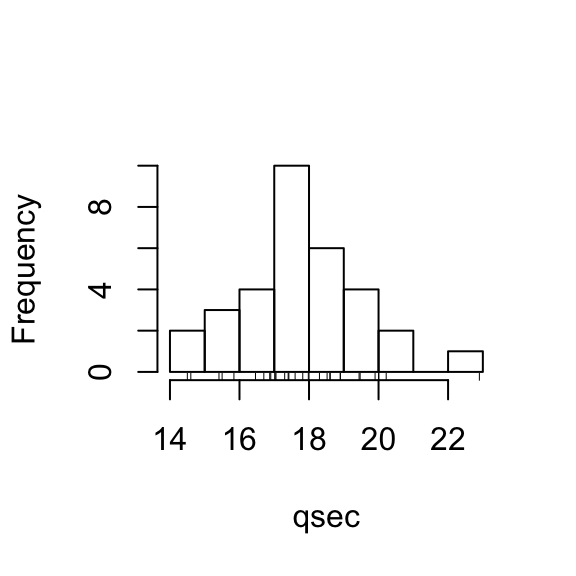

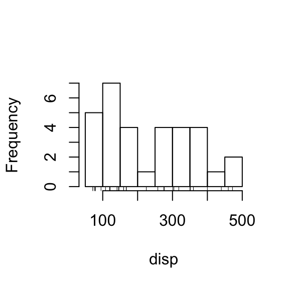

```r
# load the cars dataset that is already in R
data(mtcars)
crs <- mtcars
# a for loop to make lots of plots
for(foo in c("wt", "hp", "mpg", "qsec", "disp")){
     hist(crs[ , foo], main = NULL, xlab = foo)
     rug(crs[ ,foo])
}
```

```r
## while loops repeat until something happens
x <- 1
while(x < 10){
     print(x + 100)
     x <- x + 1
}
```

```
## [1] 101
## [1] 102
## [1] 103
## [1] 104
## [1] 105
## [1] 106
## [1] 107
## [1] 108
## [1] 109
```

Exercises(2):

### 2.1 Write a for loop to print the numbers 1:100

```r
################################  EXAMPLE 2 ################################
# if/else
################################  EXAMPLE 2 ################################

# you can use "if", "else", and "else if" inside loops to do different things

for(i in 1:10){
     if(i > 5) print(i + 100)
     else print("hello")
}
```

```
## [1] "hello"
## [1] "hello"
## [1] "hello"
## [1] "hello"
## [1] "hello"
## [1] 106
## [1] 107
## [1] 108
## [1] 109
## [1] 110
```

```r
# same
for(i in 1:10){
     if(i > 5){
         print(i + 100)
     }
     else{
          print("hello")
     }
}
```

```
## [1] "hello"
## [1] "hello"
## [1] "hello"
## [1] "hello"
## [1] "hello"
## [1] 106
## [1] 107
## [1] 108
## [1] 109
## [1] 110
```

```r
# example with data frame
for(nums in 1:length(df1$number1)){
     print(nums)
}
```

```
## [1] 1
## [1] 2
## [1] 3
## [1] 4
```

```r
for(nums in 1:length(df1$number1)){
     print(as.character(df1$person[nums]))
}
```

```
## [1] "bob"
## [1] "sue"
## [1] "jack"
## [1] "ann"
```

```r
for(nums in 1:length(df1$number1)){
     if(as.character(df1$person[nums]) == "sue"){
          print("sue was here")
     }
     else if(as.character(df1$person[nums]) == "bob"){
          print("bob was here")
     }
     else print("ann or jack")
}
```

```
## [1] "bob was here"
## [1] "sue was here"
## [1] "ann or jack"
## [1] "ann or jack"
```

```r
# example of making a new vector
vec1 <- rep(NA, nrow(df1))
for(nums in 1:length(df1$number1)){
     if(as.character(df1$person[nums]) == "sue"){
          vec1[nums] <- ("sue was here")
     }
     else if(as.character(df1$person[nums]) == "bob"){
          vec1[nums] <- ("bob was here")
     }
     else vec1[nums] <- ("ann or jack")
}

vec1
```

```
## [1] "bob was here" "sue was here" "ann or jack"  "ann or jack"
```

Exercises(2, cont’):

### 2.2 Write one for loop for the numbers 1:100.

- If the number is > 25, print “low”
- If the number is >= 25 and <= 75, print “middle”
- If the number is > 75, print “High”

### Write a for loop that cycles through the columns of the mtcars.txt dataset (called “crs”, earlier), and makes a histogram, only if the column is numeric.

To check if a variable is numeric, use “is.numeric(…)”

## Apply functions

```r
################################  EXAMPLE 2 ################################
# apply functions
################################  EXAMPLE 2 ################################

# here's a simple function
x2 <- function(x) x^2

x2(5)
```

```
## [1] 25
```

```r
# here is a function
trimMean <- function(vect) {
     qs <- quantile(vect, probs = c(.10, .90))
     mean(vect[vect > qs[1] & vect < qs[2]])
}

nums <- c(1:100, 1000)
nums2 <- c(50:100, 1500, 1)
nums3 <- c(1,3,5,6,7,7,5,4,34,.76,87,8,8,8,6,5,4.4,4,56,7,7,88,33)

# make a new list, from our numbers
listNums <- list(nums, nums2, nums3)

trimMean(nums)
```

```
## [1] 51
```

```r
trimMean(nums2)
```

```
## [1] 75
```

```r
trimMean(nums3)
```

```
## [1] 9.317647
```

```r
# trimMean(listNums) doesn't work
# trimMean(nums, nums2) #doesn't work
trimMean(c(nums, nums2, nums3)) # doesn't give three different numbers
```

```
## [1] 54.32624
```

```r
# we could write a for loop
listMNS <- numeric(length(listNums))
for(i in 1:length(listNums)){
     listMNS[i] <- trimMean(listNums[[i]])
}
listMNS
```

```
## [1] 51.000000 75.000000  9.317647
```

```r
# or we could use apply
sapply(listNums, FUN = trimMean)
```

```
## [1] 51.000000 75.000000  9.317647
```

```r
## Apply functions are often faster than loops

# this for loop is slow, because we grow the newVec variable on every iteration of the loop
# note: loop isn't needed here, you could just use 1:30000 + 100 to get a new vector.
system.time({
     newVec <- numeric()
     for(ii in 1:30000){
          newVec[ii] <- ii + 100
     }
})
```

```
##    user  system elapsed
##   0.931   0.209   1.142
```

```r
head(newVec)
```

```
## [1] 101 102 103 104 105 106
```

```r
## sapply function (for illustration only....sapply is not necessary here)
# first, we write a function for what we want to happen
x100 <- function(x) x + 100


# apply that function to a vector
system.time({
     newVec.sa <- sapply(X = 1:100000, FUN = x100)
})
```

```
##    user  system elapsed
##   0.063   0.002   0.065
```

```r
head(newVec.sa)
```

```
## [1] 101 102 103 104 105 106
```

```r
## you can speed up a for-loop by pre-allocating space
system.time({

     newVec <- numeric(100000)
     for(ii in 1:100000){
          newVec[ii] <- ii + 100
     }
})
```

```
##    user  system elapsed
##   0.084   0.000   0.085
```

```r
## you can use apply functions on a data frame

# say you want to calculate the trimmed mean (removing the max and min) for several columns in your data frame

# this function trims the min and max of a vector and returns the mean
tMean <- function(x){
     x <- x[x != min(x, na.rm = TRUE) & x != max(x, na.rm = TRUE)]
     return(mean(x, na.rm=TRUE))
}

tMean(c(1:100, 10000, NA, NA))
```

```
## [1] 51
```

```r
mean(c(1:100, 10000, NA), na.rm =TRUE)
```

```
## [1] 149.0099
```

```r
flr <- read.csv("Datasets/CallinPollen.csv")

# you could use a for loop
tms <- numeric()
for(ii in c("temp", "humidity", "int", "slope")){
     tms[ii] <- tMean(flr[, ii])
}

tms
```

```
##         temp     humidity          int        slope
## 25.302283105 55.290476190  0.094796074  0.008759418
```

```r
# or you could use apply
# apply allows you to choose the margin -- I think it converts to a matrix first
apply(X = flr[, c("temp", "humidity", "int", "slope")], MARGIN = 2, FUN = tMean)
```

```
##         temp     humidity          int        slope
## 25.302283105 55.290476190  0.094796074  0.008759418
```

```r
# same thing
sapply(X = flr[, c("temp", "humidity", "int", "slope")], FUN = tMean)
```

```
##         temp     humidity          int        slope
## 25.302283105 55.290476190  0.094796074  0.008759418
```

Exercises(2, cont’):

### 2.3 The following function prints the max or the highest level of a factor.

```r
maxHighF <- function(thing) {
     if(is.numeric(thing)) return(max(thing, na.rm = TRUE))
     else if(is.factor(thing)) return(levels(thing)[length(levels(thing))])
     else return(NA)
}


maxHighF(crs$hp) # works
```

```
## [1] 335
```

```r
maxHighF(flr$trt) # works
```

```
## [1] "Humidifier"
```

```r
maxHighF(flr[, c("trt", "humidity")]) # doesn't work
```

```
## [1] NA
```

### Apply this function to every column of the flower data frame, using sapply or lapply

Note: This won’t work with just “apply”

## Writing your own functions

```r
# functions take in something, do something, then output something

# example 1
printNum.plus5 <- function(num){
     print(num + 5)
}


printNum.plus5(5)
```

```
## [1] 10
```

```r
printNum.plus5(1000)
```

```
## [1] 1005
```

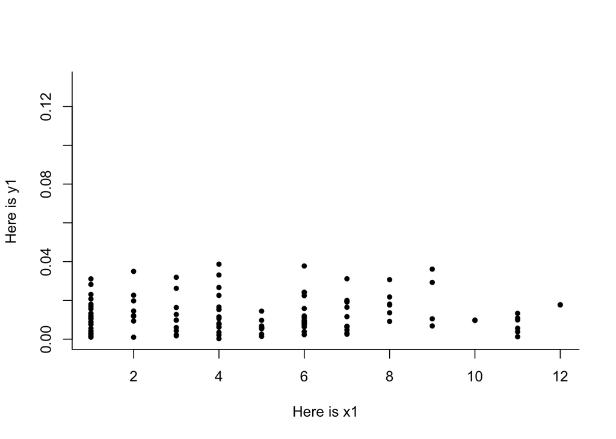

```r
# example 2
plotWithAxisLabels <- function(x1, y1){
     plot(x = x1, y = y1, xlab = "Here is x1", ylab = "Here is y1",
          bty = "l", pch = 20)
}

plotWithAxisLabels(x1 = flr$distance, y1 = flr$slope)
```

```r
####### Functions to show Bonferroni Correction #######

# this function gets 20 random samples, and conducts one-sample t-tests on each of the samples
# it returns the number of p-values that are less than 0.05
pvTst <- function(){
     # get normally distributed samples, with mean = 0, and sd = 1
     samps  <- lapply(1:20 , function(o) rnorm(100))

     # get p-values from t-test
     pvs <- sapply(1:length(samps), function(x) t.test(samps[[x]])$p.value)

     # returns the number of p-values that are significant
     sum(pvs < 0.05)
}

# test the function
pvTst()
```

```
## [1] 3
```

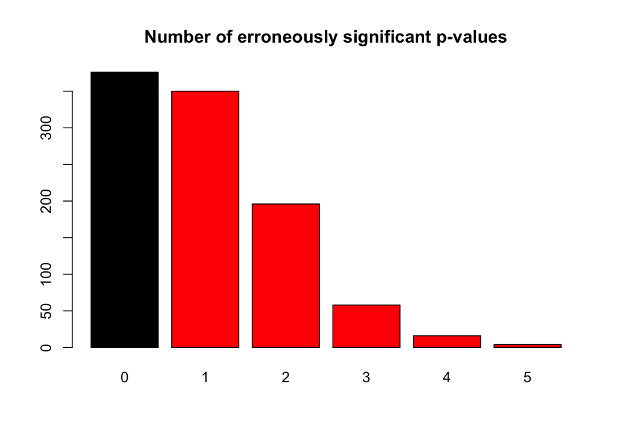

```r
# imagine 1000 studies, each doing 20 tests on random, normal data
Sigs <- replicate(1000, pvTst())

barplot(table(Sigs), main = "Number of erroneously significant p-values", col = (as.numeric(names(table(Sigs))) > 0) + 1)
```

```r
mean(Sigs > 0)  # probability of erroneously rejecting at least one test
```

```
## [1] 0.624
```

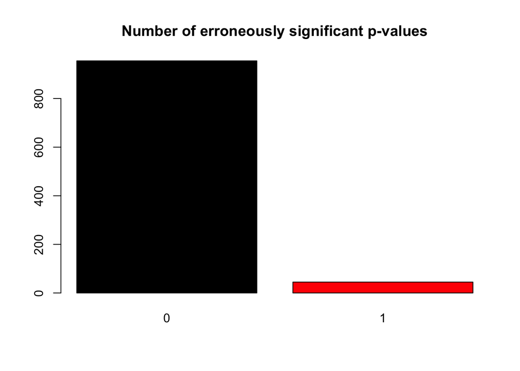

```r
pvBonf <- function(){
     # sample random data
     samps  <- lapply(1:20 , function(o) rnorm(20))

     # get p-values for one-sample t.test
     pvs <- sapply(1:length(samps), function(x) t.test(samps[[x]])$p.value)

     # these p-values have been adjusted with the Bonferroni correction
     pvs.bonf <- p.adjust(pvs, method = "bonferroni")

     # returns the number of p-values that are significant
     sum(pvs.bonf < 0.05)

}

sigs.Bonf <- replicate(1000, pvBonf())
barplot(table(sigs.Bonf),main = "Number of erroneously significant p-values", col = (as.numeric(names(table(sigs.Bonf))) > 0) + 1)
```

```r
mean(sigs.Bonf > 0) # probability of erroneously rejecting at least one test
```

```
## [1] 0.045
```

```r
# main take-away: if 1000 studies had done 20 different tests on random, nonsignificant data, then
# using Bonferrroni adjustment would ensure that ~5% of those studies erroneously rejected at least one
# test
```

Exercises(3):

### 3.1 Write a function that takes a column name from the flr dataframe as an argument. If the column is numeric, make a scatterplot of x = that column, y = int, with points colored red. If the column is a factor, then make a boxplot of x = column, y = int, where the boxes are filled with blue.

#### Test the function with the “trt” and “temp” columns

You can read in the dataset like this:

```
 flr <- read.csv("Datasets/CallinPollen.csv")
```

Extra Practice:

### E.1 Read in the “loblolly.txt” dataset, if you haven’t already. Call it “lob”. Use ggplot() to plot a scatterplot (geom_point()) with x= age, y = height.

### E.2 Using the “lob” dataframe, convert “age” to a factor.

```
 lob$age <- as.factor(lob$age)
```

### Now make a boxplot where x = age, and y = height with ggplot()

### E.3 Using the “lob” dataframe, add points to the boxplot from above. *Advanced change the color of the points, based on the “Seed” variable from the “lob” dataframe (you may want to convert it to a factor first)*

### E.4 Change the theme from your previous plot to the “classic” theme with theme_classic().